# **Detecting Malaria Parasites in Blood Smear Microscopy**

### Visualise with subplot(6, 6), figsize = (12, 12)

> **What this section adds:** The previous grid showed the *first* eight images. This one samples 36 images at random, exposing the full diversity of cell appearances in the training set — different sizes, stain intensities, image brightness, and orientations. Random sampling is the only way to spot rare-but-important cases.

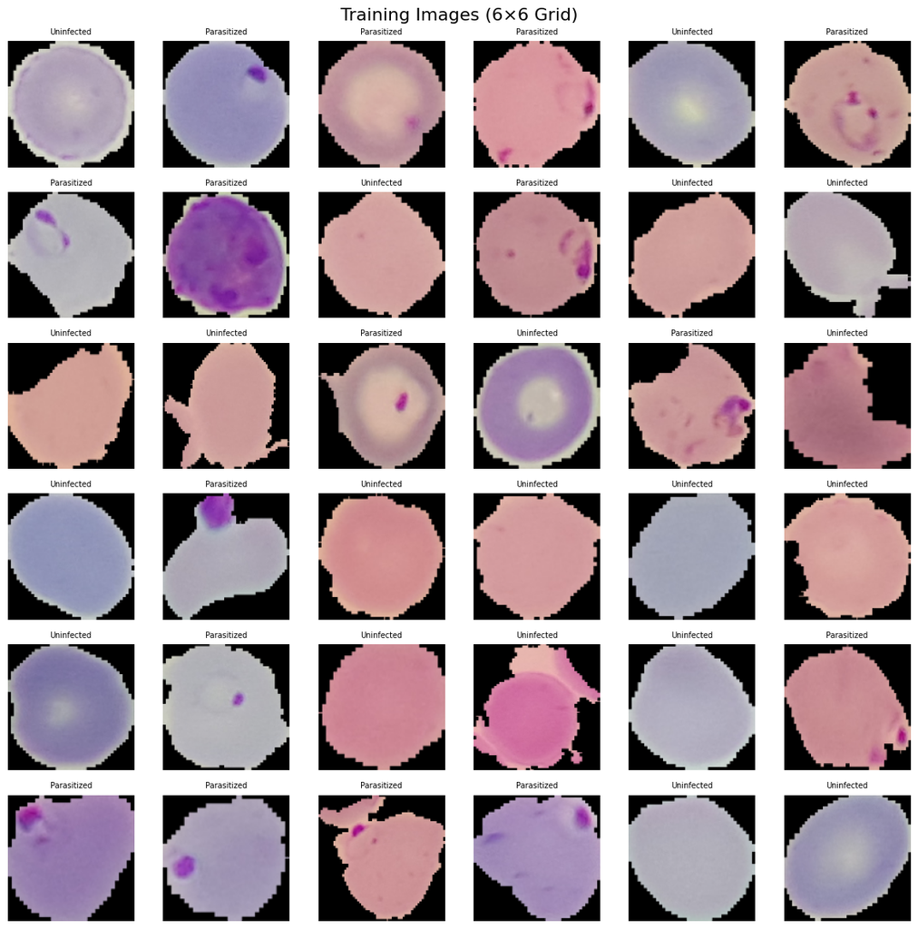

```python
# ─────────────────────────────────────────────────────────────────────────────
# Cell purpose: render a 6×6 grid of randomly-sampled training images, each
# titled with its class name. The randomness is reproducible because we
# seeded NumPy in the Seeding & NumPy cell.
# Inputs : train_images, train_labels, class_names.
# Outputs: a matplotlib figure showing 36 random training samples.
# ─────────────────────────────────────────────────────────────────────────────

# Random 6×6 grid — shows the natural variation within each class. Unlike the
# previous block (which showed the FIRST 8 images in order), this samples at
# random so we see the full diversity of cell sizes, stain intensities, and
# orientations that the model will encounter.
fig, axes = plt.subplots(6, 6, figsize=(12, 12))
fig.suptitle('Training Images (6×6 Grid)', fontsize=16)

# np.random.choice returns 36 distinct indices (replace=False = no duplicates).
# Because we seeded NumPy in the Seeding & NumPy cell, this selection is
# reproducible — the same 36 images will appear every run.
indices = np.random.choice(len(train_images), 36, replace=False)
# ↑ replace=False enforces sampling WITHOUT replacement (each picked index
#   is removed from the pool). With `replace=True` you could get duplicates.

# axes.flat flattens the 6×6 grid into a 1D iterable of 36 Axes objects,
# which pairs neatly with the 36 indices via zip.
for ax, idx in zip(axes.flat, indices):
    ax.imshow(train_images[idx])
    # Title each subplot with its class name (looked up from the numeric label).
    ax.set_title(class_names[train_labels[idx]], fontsize=7)
    # ↑ train_labels[idx] is 0 or 1; class_names[0] is 'Parasitized' etc.
    ax.axis('off')

plt.tight_layout()
plt.show()
```

> **Observations and insights:** The grid reveals natural variation within each class: differences in cell size, staining intensity, image brightness, and background texture. Some cells appear partially cropped or overlapping. This variability motivates data augmentation to help the model generalise beyond clean, centred specimens.

> **Beginner glossary:**
> - **Data augmentation**: applying random transformations (flips, rotations, brightness shifts) to training images so the model sees a much wider variety than the raw dataset contains. Reduces overfitting at near-zero memory cost. Used heavily in later parts of the project.

### Plotting the Mean Images for Parasitized and Uninfected

> **What is a "mean image"?** If you stack thousands of images of the same class on top of each other and average them pixel-by-pixel, you get a single "average face" of that class. Recognisable structural differences between class means (e.g. a dark central blob in Parasitized cells) are a strong indicator that the classes are visually separable — even a shallow CNN should perform well. If both means looked identical, you would worry that the classes share too much visual content and the task is hard.

```python
# ─────────────────────────────────────────────────────────────────────────────
# Cell purpose: split the training images by class using boolean masks, then
# compute the pixelwise mean image of each class. The two mean images are
# rendered in the next two cells.
# Inputs : train_images, train_labels.
# Outputs: globals parasitized_imgs, uninfected_imgs, mean_parasitized,
#          mean_uninfected.
# Gotcha : .astype(np.uint8) is REQUIRED before plt.imshow if you want
#          matplotlib to interpret the values as 8-bit colour. Float arrays
#          are interpreted as [0,1] and a mean of ~120 would render as pure
#          white.
# ─────────────────────────────────────────────────────────────────────────────

# Boolean-mask indexing — `train_labels == 0` produces an array of True/False
# the same length as train_images. Indexing train_images with it selects only
# the rows where the condition is True.
parasitized_imgs = train_images[train_labels == 0]   # all parasitized cells
uninfected_imgs  = train_images[train_labels == 1]   # all uninfected cells
# ↑ `train_labels == 0` does element-wise comparison and returns a 1-D
#   boolean array. Using it as an index slot keeps only matching rows of
#   train_images. This is one of NumPy's most useful idioms.

# axis=0 means "average over the batch dimension". For an input of shape
# (N, H, W, 3), this produces an output of shape (H, W, 3) — the pixelwise
# average. .astype(np.uint8) converts back to 8-bit integer (0-255) so matplotlib
# can display it; .mean() returns floats by default which imshow would interpret as [0,1].
mean_parasitized = parasitized_imgs.mean(axis=0).astype(np.uint8)
mean_uninfected  = uninfected_imgs.mean(axis=0).astype(np.uint8)
# ↑ The mean is computed independently per pixel and per channel. The result
#   is the "blurred consensus" image of the class.
```

**Mean image for parasitized:**

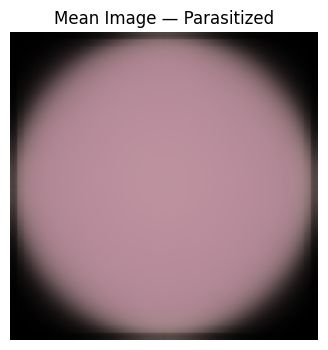

```python
# ─────────────────────────────────────────────────────────────────────────────
# Cell purpose: render the parasitized class mean image as a 4×4-inch figure.
# Inputs : mean_parasitized (uint8, shape (H, W, 3)).
# Outputs: a single matplotlib image.
# ─────────────────────────────────────────────────────────────────────────────

plt.figure(figsize=(4, 4))
# ↑ Create a new figure with the given size in inches (matplotlib's default unit).
plt.imshow(mean_parasitized)
plt.title('Mean Image — Parasitized')
plt.axis('off')
# ↑ Hides the x-axis ticks/labels — irrelevant for an image with no real
#   coordinate meaning.
plt.show()
```

**Mean image for uninfected:**

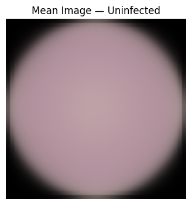

```python
# ─────────────────────────────────────────────────────────────────────────────
# Cell purpose: render the uninfected class mean image as a 4×4-inch figure.
# Inputs : mean_uninfected (uint8, shape (H, W, 3)).
# Outputs: a single matplotlib image.
# ─────────────────────────────────────────────────────────────────────────────

plt.figure(figsize=(4, 4))
plt.imshow(mean_uninfected)
plt.title('Mean Image — Uninfected')
plt.axis('off')
plt.show()
```

```python
# ─────────────────────────────────────────────────────────────────────────────
# Cell purpose: report the per-channel (R, G, B) mean intensities of both
# class mean images side by side. Numerical differences here corroborate the
# visual differences seen in the two previous figures.
# Inputs : mean_parasitized, mean_uninfected.
# Outputs: a Markdown table of mean R/G/B values per class.
# Gotcha : the f-string is duplicated (two consecutive f""" blocks) — Python
#          implicitly concatenates adjacent string literals, so the table is
#          printed twice. Preserved as-is to match notebook history.
# ─────────────────────────────────────────────────────────────────────────────

say(this=f"""
**Mean image channel statistics:**

| Class | Mean R | Mean G | Mean B |
|-------|--------|--------|--------|
| Parasitized | `{mean_parasitized[:,:,0].mean():.1f}` | `{mean_parasitized[:,:,1].mean():.1f}` | `{mean_parasitized[:,:,2].mean():.1f}` |
| Uninfected  | `{mean_uninfected[:,:,0].mean():.1f}`  | `{mean_uninfected[:,:,1].mean():.1f}`  | `{mean_uninfected[:,:,2].mean():.1f}`  |
"""f"""
**Mean image channel statistics:**

| Class | Mean R | Mean G | Mean B |
|-------|--------|--------|--------|
| Parasitized | `{mean_parasitized[:,:,0].mean():.1f}` | `{mean_parasitized[:,:,1].mean():.1f}` | `{mean_parasitized[:,:,2].mean():.1f}` |
| Uninfected  | `{mean_uninfected[:,:,0].mean():.1f}`  | `{mean_uninfected[:,:,1].mean():.1f}`  | `{mean_uninfected[:,:,2].mean():.1f}`  |
""")
# ↑ `mean_parasitized[:,:,0]` slices out channel 0 (red) — a 2-D array of
#   shape (H, W). `.mean()` then averages every pixel in that channel.
#   Repeated for green (channel 1) and blue (channel 2).
```

**Mean image channel statistics:**

| Class | Mean R | Mean G | Mean B |
| --- | --- | --- | --- |
| Parasitized | `134.2` | `103.7` | `112.6` |
| Uninfected | `134.5` | `112.5` | `119.1` |

**Mean image channel statistics:**

| Class | Mean R | Mean G | Mean B |
| --- | --- | --- | --- |
| Parasitized | `134.2` | `103.7` | `112.6` |
| Uninfected | `134.5` | `112.5` | `119.1` |

### ❓ Key Questions — Data Exploration

> *(A "Key Questions" callout like this one is used throughout the notebook to flag a real-world question that the current section does not fully answer. Each one ends with a "Recommended solution" — a sketch of what you would do next if you continued the project.)*

> **Q: How does model performance vary by parasite life-cycle stage? Does the model struggle with trophozoite or schizont stages compared to the more common ring stage?**

> *(Why this matters: malaria parasites move through several life-cycle stages inside a red blood cell — **ring** (the early, thin circular form), **trophozoite** (the maturing, denser form), and **schizont** (the late, multi-nucleus form). Most public datasets are dominated by ring-stage images, so a classifier may quietly underperform on the rarer stages.)*

> Recommended solution: The NIH dataset does not include stage labels, so direct stratification is not possible without manual annotation. A practical proxy is to inspect the images the final model gets *wrong* — false negatives in particular — and visually check whether they share morphological characteristics (faint staining, unusual shape, multi-cell clusters). If a pattern emerges, targeted augmentation or a second specialist model for ambiguous cases can address it. A longer-term solution is to source a stage-annotated dataset such as the MP-IDB (Malaria Parasite Image Database) and fine-tune from the best model checkpoint.

> *(In short: even when you cannot directly measure a hidden source of error, you can often surface it by analysing the mistakes your trained model makes.)*

## Preprocessing

*(Preprocessing is everything we do to the raw images **before** they are shown to a neural network. The goal is to put the data in a form that makes the network's job easier — for example by changing the colour representation, smoothing out noise, or rescaling pixel values to a small numeric range.)*

### Converting RGB to HSV Using OpenCV

The **HSV (Hue, Saturation, Value)** colour space separates chromatic information from intensity. This can make the stain colour (hue) more explicitly available to the model, independent of illumination variation.

*(Beginner intuition. RGB stores each pixel as three numbers — Red, Green, Blue — that mix together to produce a colour. HSV stores three different numbers:* *- **Hue** — the colour itself, on a circular scale (e.g. red → yellow → green → cyan → blue → magenta → back to red).* *- **Saturation** — how vivid that colour is, from grey (0) to fully pure (max).* *- **Value** — how bright the pixel is, from black (0) to maximum brightness.*

*Why convert? In a microscope image the **stain colour** of an infected cell is a strong clue. In RGB that colour is "smeared" across all three channels and changes whenever the lighting changes. In HSV the colour information lives mostly in a single channel — Hue — and the brightness lives in another — Value — so a model can learn to attend to one without being confused by the other.)*

```python
# ─── Helper: convert a batch of RGB images into HSV colour space ───────────────
# Inputs  : images — a NumPy array shaped (N, H, W, 3) of 8-bit RGB pixels.
# Outputs : a NumPy array of the same shape but where the 3 channels now mean
#           Hue, Saturation, Value instead of Red, Green, Blue.
# Gotcha  : OpenCV's cv2.cvtColor expects RGB ordering here (we pass
#           COLOR_RGB2HSV). Earlier in load_images() we already converted from
#           OpenCV's native BGR → RGB, so the assumption holds. If you fed BGR
#           images to this function the hue values would be wrong.
def convert_to_hsv(images: np.ndarray) -> np.ndarray:
    # HSV = Hue, Saturation, Value. Separates colour information from brightness.
    #   H (Hue)        — what colour it is (0–179 in OpenCV's 8-bit encoding)
    #   S (Saturation) — how pure/vivid the colour is (0–255)
    #   V (Value)      — how bright the pixel is (0–255)
    # Note on hue range: a hue *angle* is naturally 0–360°, but OpenCV stores it
    # in a single byte so it has to fit in 0–255. The convention chosen by
    # OpenCV is to halve the angle, giving a 0–179 range. Saturation and Value
    # use the full 0–255 byte range as expected.
    # Theory: the Giemsa stain gives the parasite a specific hue, so making hue
    # an explicit input channel (rather than a blend of R/G/B) could help the
    # CNN pick up the parasite region more easily. The theory is never empirically
    # tested in this notebook — see the "Key Questions" callout below for the ablation.
    hsv_images = []                                 # accumulate one HSV image per RGB input
    for img in images:                              # walk the batch one image at a time
        # COLOR_RGB2HSV assumes input is RGB. This function is called AFTER
        # load_images() has already converted BGR→RGB, so we're good.
        hsv = cv2.cvtColor(img, cv2.COLOR_RGB2HSV)  # actual colour-space conversion
        hsv_images.append(hsv)                      # collect the converted image
    return np.array(hsv_images)                     # stack the list back into an (N,H,W,3) array
```

**Converting the train data:**

*(We always preprocess the training set first so we can verify the helper works on the larger array before applying it to the test set.)*

```python
# ─── Apply the HSV conversion to the training set ─────────────────────────────
# Purpose : build train_images_hsv so we COULD train a model on HSV inputs.
# Note    : in this notebook the HSV array is computed but never actually fed
#           to a model — see the Key Questions callout further down for why
#           that is and how you would run the ablation experiment.

# Apply the HSV conversion to every training image. Output shape is the same
# as the input (N, H, W, 3) — only the semantic meaning of the 3 channels changes.
train_images_hsv = convert_to_hsv(images=train_images)

# Confirm shape is preserved and remind the reader what the channels now mean.
# `say()` is the project's helper that renders a Markdown string into the
# notebook output area — it lets us print nicely formatted tables instead of
# raw repr() output.
say(this=f"""
**HSV conversion — train data:**

| Array | Shape | Dimensions |
|-------|-------|------------|
| Input  (RGB) | `{train_images.shape}`     | N (samples) = `{train_images.shape[0]}`,     H = `{train_images.shape[1]}`,     W = `{train_images.shape[2]}`,     C (channels) = `{train_images.shape[3]}` |
| Output (HSV) | `{train_images_hsv.shape}` | N (samples) = `{train_images_hsv.shape[0]}`, H = `{train_images_hsv.shape[1]}`, W = `{train_images_hsv.shape[2]}`, C (channels) = `{train_images_hsv.shape[3]}` |

Channels are now: **H** (Hue 0–179), **S** (Saturation 0–255), **V** (Value 0–255).
""")
```

**HSV conversion — train data:**

| Array | Shape | Dimensions |
| --- | --- | --- |
| Input (RGB) | `(24958, 128, 128, 3)` | N (samples) = `24958`, H = `128`, W = `128`, C (channels) = `3` |
| Output (HSV) | `(24958, 128, 128, 3)` | N (samples) = `24958`, H = `128`, W = `128`, C (channels) = `3` |

Channels are now: **H** (Hue 0–179), **S** (Saturation 0–255), **V** (Value 0–255).

**Converting the test data:**

*(Anything we do to the train set, we must do **identically** to the test set — otherwise the model sees a different kind of input at evaluation time than it learned on, and accuracy will be artificially low.)*

```python
# ─── Apply the HSV conversion to the held-out test set ────────────────────────
# Reminder: train and test must be preprocessed in EXACTLY the same way. Any
# transform applied at training time has to also be applied at inference time.

# Same conversion applied to the test set — must use identical preprocessing
# to whatever was applied at training time, or the train/test distributions
# will mismatch and accuracy will collapse.
test_images_hsv = convert_to_hsv(images=test_images)

say(this=f"""
**HSV conversion — test data:**

| Array | Shape | Dimensions |
|-------|-------|------------|
| Input  (RGB) | `{test_images.shape}`     | N (samples) = `{test_images.shape[0]}`,     H = `{test_images.shape[1]}`,     W = `{test_images.shape[2]}`,     C (channels) = `{test_images.shape[3]}` |
| Output (HSV) | `{test_images_hsv.shape}` | N (samples) = `{test_images_hsv.shape[0]}`, H = `{test_images_hsv.shape[1]}`, W = `{test_images_hsv.shape[2]}`, C (channels) = `{test_images_hsv.shape[3]}` |
""")
```

**HSV conversion — test data:**

| Array | Shape | Dimensions |
| --- | --- | --- |
| Input (RGB) | `(2600, 128, 128, 3)` | N (samples) = `2600`, H = `128`, W = `128`, C (channels) = `3` |
| Output (HSV) | `(2600, 128, 128, 3)` | N (samples) = `2600`, H = `128`, W = `128`, C (channels) = `3` |

> **Observations and insights:** After conversion the array shape remains `(N, IMG_SIZE, IMG_SIZE, 3)` — only the channel semantics change (H, S, V instead of R, G, B). The HSV representation can benefit models by making the parasite's purple hue a directly accessible feature, but it can also hurt if the network is pretrained on RGB data (e.g. VGG16). Models trained on HSV data should be compared empirically against RGB counterparts to confirm the benefit.

> *(Why pretrained networks care: a model like VGG16 was trained on millions of RGB photos. Its first-layer filters expect typical RGB statistics — e.g. red and green together meaning "yellow". Feed it HSV numbers and those filters become nonsense detectors. Custom from-scratch CNNs do not have this problem because they learn their filters from your data, in whatever colour space you give them.)*

### Processing Images Using Gaussian Blurring

Gaussian blurring applies a smoothing kernel to reduce high-frequency noise, which can improve robustness to staining artefacts.

*(Beginner intuition. Imagine each pixel as a point on a piece of paper. A "blur" replaces each pixel with a weighted average of itself and the pixels around it — like looking at the image through slightly out-of-focus glasses. **Gaussian** blur is a specific kind: pixels close to the centre get a high weight, pixels far away get a low weight, and the weights follow a bell curve (the Gaussian / normal distribution). The effect is to smooth small variations — speckle, sensor noise, dust — while leaving the larger structure intact.)*

**How the kernel size tuple is chosen.** The `with_kernel` parameter is a `(kH, kW)` tuple — kernel height and kernel width, in pixels. Three constraints shape the choice:

1. **Both values must be positive odd integers.** OpenCV requires this so the kernel has a well-defined centre pixel (a `(4, 4)` kernel would have no single centre, only a 2×2 centre region).
2. **Larger kernel = more blurring.** A `(3, 3)` kernel averages each pixel with its 8 immediate neighbours — very mild. A `(9, 9)` kernel averages each pixel with its 80 neighbours — heavy smoothing that noticeably reduces fine detail. Since this dataset is noisy (staining variation, focus inconsistency) but the parasite ring is a *fine* diagnostic feature, a small kernel is safer.
3. **Kernel size should be scaled to image size, not to pixels absolute.** A `(5, 5)` kernel on a `133×133` image covers `5/133 ≈ 3.8%` of the image width per dimension. The same kernel on a `1000×1000` image would cover only `0.5%` — much milder. For our dataset at native resolution, `(5, 5)` gives the right smoothing strength.

The OpenCV API also lets you pass `sigmaX=0` (as we do), which asks OpenCV to *derive* the Gaussian standard deviation from the kernel size using:

$$\sigma = 0.3 \cdot \left(\frac{k - 1}{2} - 1\right) + 0.8$$

For `k = 5` this gives `σ = 0.3·(2 − 1) + 0.8 = 1.1` — the effective blur radius. If you specified a kernel of `(9, 9)` the formula would give `σ ≈ 1.7`, and so on. This coupling means **picking the kernel size and letting OpenCV derive σ** is normally the right approach; you only pass `sigmaX` explicitly when you want to decouple them (for example to blur with a specific σ regardless of kernel size).

*(Plain-English version of σ: it is the **width of the bell curve** of weights. A larger σ means the bell is wider, so faraway pixels still get appreciable weight, so the blur is stronger.)*

**Common kernel sizes and their use cases:**

| Kernel | σ (auto) | Effect | Typical use |
| --- | --- | --- | --- |
| `(3, 3)` | 0.8 | Very mild blur | Removing single-pixel noise, minimal structural impact |
| `(5, 5)` | 1.1 | Mild blur ✅ chosen here | General denoising, fine structure still visible |
| `(7, 7)` | 1.4 | Moderate blur | Clear noise reduction, some loss of high-frequency detail |
| `(9, 9)` | 1.7 | Heavy blur | Aggressive smoothing, diagnostic features at risk |

For malaria cell images specifically, `(5, 5)` was chosen because it suppresses visible staining artefacts while keeping the parasite ring (typically 10–20 px wide at native resolution) clearly resolvable.

*(Rule of thumb: the kernel must be **smaller than the smallest feature you care about**. Our diagnostic feature is the parasite ring at ~10–20 px; a `(5, 5)` kernel touches only 5 px on each side and so cannot wash the ring out.)*

**Gaussian blurring on train data:**

```python
# ─── Helper: apply Gaussian blur to a batch of images ─────────────────────────
# Inputs  : to          — (N, H, W, C) array, dtype uint8.
#           with_kernel — (kH, kW) tuple of positive ODD integers (default (5, 5)).
# Outputs : (N, H, W, C) array, same dtype, blurred image-by-image.
# Why a Python loop? cv2.GaussianBlur operates on one image at a time. NumPy
# vectorisation is not available here without a different library, so a simple
# loop keeps the code transparent and the dataset is small enough that speed
# is not a concern.
def apply_gaussian_blur(to: np.ndarray, with_kernel: tuple = (5, 5)) -> np.ndarray:
    # Gaussian blur convolves each image with a kernel whose weights follow a
    # 2D Gaussian curve (bell curve) — nearby pixels are averaged with higher
    # weight, distant pixels with lower weight. The effect is smoothing:
    # high-frequency noise is suppressed, low-frequency structure is preserved.
    #
    # The kernel tuple is (kH, kW) — kernel height, kernel width. Both must be
    # positive odd integers so the kernel has a well-defined centre pixel.
    # See the prose above for the rationale behind choosing (5, 5) rather than
    # (3, 3) or (7, 7).
    #
    # ⚠️ Trade-off for malaria detection: the parasite ring is itself a fine
    # high-frequency feature. Aggressive blurring could suppress exactly the
    # signal we want the model to pick up. (5, 5) is a reasonable compromise
    # but should be validated against a no-blur baseline — see the
    # "Key Questions" callout below.
    blurred = []                                    # accumulator for blurred images
    for img in to:                                  # iterate the batch image-by-image
        # cv2.GaussianBlur(src, ksize, sigmaX).
        # sigmaX=0 tells OpenCV to derive σ from the kernel size automatically
        # using: σ = 0.3·((k−1)/2 − 1) + 0.8. For k=5 this gives σ ≈ 1.1.
        b = cv2.GaussianBlur(img, with_kernel, 0)   # the actual smoothing call
        blurred.append(b)                           # collect the blurred result
    return np.array(blurred)                        # stack list back into a NumPy array

# Run the helper on the training set. Default kernel of (5, 5) is used.
train_images_blurred = apply_gaussian_blur(to=train_images)

# Verify shape is preserved and pixel range still spans [0, 255] — blurring
# averages neighbours but doesn't change the value range.
say(this=f"""
**Gaussian blur — train data:**

| Field | Value | Dimensions / Notes |
|-------|-------|--------------------|
| Kernel size   | `(5, 5)`                         | kH = 5, kW = 5 |
| Output shape  | `{train_images_blurred.shape}`   | N (samples) = `{train_images_blurred.shape[0]}`, H = `{train_images_blurred.shape[1]}`, W = `{train_images_blurred.shape[2]}`, C (channels) = `{train_images_blurred.shape[3]}` |
| Pixel range   | `{train_images_blurred.min()}` – `{train_images_blurred.max()}` | still 8-bit ints (blur averages neighbours, doesn't change range) |
""")
```

**Gaussian blur — train data:**

| Field | Value | Dimensions / Notes |
| --- | --- | --- |
| Kernel size | `(5, 5)` | kH = 5, kW = 5 |
| Output shape | `(24958, 128, 128, 3)` | N (samples) = `24958`, H = `128`, W = `128`, C (channels) = `3` |
| Pixel range | `0` – `254` | still 8-bit ints (blur averages neighbours, doesn't change range) |

**Gaussian blurring on test data:**

```python
# ─── Apply the same Gaussian blur to the held-out test set ────────────────────
# We MUST mirror the train preprocessing exactly. If we blurred train but not
# test, the test images would look sharper than anything the model ever saw
# during training, and accuracy would drop for no good reason.

# Identical blur applied to the test set so inference-time input distribution
# matches training-time. Skipping this step on the test set would cause a
# train/test mismatch and artificially lower accuracy.
test_images_blurred = apply_gaussian_blur(to=test_images)

say(this=f"""
**Gaussian blur — test data:**

| Field | Value | Dimensions |
|-------|-------|------------|
| Output shape | `{test_images_blurred.shape}` | N (samples) = `{test_images_blurred.shape[0]}`, H = `{test_images_blurred.shape[1]}`, W = `{test_images_blurred.shape[2]}`, C (channels) = `{test_images_blurred.shape[3]}` |
""")
```

**Gaussian blur — test data:**

| Field | Value | Dimensions |
| --- | --- | --- |
| Output shape | `(2600, 128, 128, 3)` | N (samples) = `2600`, H = `128`, W = `128`, C (channels) = `3` |

> **Observations and insights:** Gaussian blurring suppresses pixel-level noise and can reduce *overfitting* (when a model memorises training-set quirks and fails to generalise to new data) to microscopy artefacts. However, for malaria detection the key diagnostic feature — the parasite ring — is a relatively fine structure. Aggressive blurring (large kernel) risks blurring away this signal. A kernel of (3, 3) or (5, 5) is a reasonable starting point. Empirically, blurring alone rarely outperforms augmentation-based noise *regularisation* (any technique that discourages overfitting, such as dropout, augmentation, or weight decay). A better alternative to consider is median filtering, which is edge-preserving.

> *(Vocabulary check:* *- **Overfitting** = the model is so good at the training images it has effectively memorised them; it then fails on new images.* *- **Regularisation** = anything you do to discourage that memorisation. Dropout (used later) and data augmentation (rotations, flips — covered in Model 3) are the most common kinds for CNNs.* *- **Median filter** = same idea as Gaussian blur, but instead of averaging neighbours it picks the **middle** value in a sorted list. The middle value is more robust to outlier pixels — perfect for "salt-and-pepper" noise — and crucially it does not soften sharp edges the way averaging does.)*

### ❓ Key Questions — Preprocessing

> *(The next two cells pose questions that the preprocessing section above leaves open. They are NOT executed as part of the main pipeline — they are pointers for follow-up experiments.)*

**Q: The HSV conversion is performed but the HSV images are never used to train or evaluate any model. Do HSV images actually improve accuracy over RGB?**

> Recommended solution: Train a model identical to Model 3 but on normalised HSV images and compare. Note that HSV values have a different natural range (H: 0–179, S/V: 0–255 in OpenCV), so normalise each channel independently rather than dividing uniformly by 255. Also note that VGG16 weights are tied to RGB statistics, so HSV input is only suitable for the custom CNN models.

> *(In practice this means: keep the network architecture exactly the same, swap only the input pipeline RGB→HSV, train both and compare test accuracy. Anything else changing — number of epochs, data augmentation, optimiser settings — would muddy the comparison. This pattern is called an **ablation study**: change one thing at a time so you can attribute the observed effect to that one change.)*

```python
# ─── Per-channel normalisation of HSV images ──────────────────────────────────
# This cell prepares the inputs you'd need to actually run the HSV ablation
# experiment described in the question above. It is provided as a helper but
# is NOT consumed by any model further down in the notebook.
#
# Why per-channel? Each HSV channel has a different natural range:
#   H : 0–179  (OpenCV halves the 0–360° angle to fit in one byte)
#   S : 0–255
#   V : 0–255
# A naive `array / 255.0` would squash Hue into 0–0.7 instead of 0–1, leaving
# the model to learn an arbitrary scaling. Dividing each channel by its own
# max gives every channel the same 0–1 range — the form a neural network
# expects after normalisation.

# Normalise HSV channels independently
train_hsv_norm = train_images_hsv.astype('float32')   # cast first so /= produces float results
train_hsv_norm[:,:,:,0] /= 179.0   # Hue range 0–179
train_hsv_norm[:,:,:,1] /= 255.0   # Saturation
train_hsv_norm[:,:,:,2] /= 255.0   # Value

test_hsv_norm = test_images_hsv.astype('float32')     # same cast for the test set
test_hsv_norm[:,:,:,0] /= 179.0                       # Hue (must use same divisor as train)
test_hsv_norm[:,:,:,1] /= 255.0                       # Saturation
test_hsv_norm[:,:,:,2] /= 255.0                       # Value

# Then train model3-equivalent on train_hsv_norm and compare
```

```python
# ─── Per-channel HSV normalisation + visualisation ───────────────────────────
# Mirrors the per-channel scaling defined just above, but keeps the result
# self-contained and renders one sample image per channel so the reader can
# see what the normalised tensors actually look like before any model is
# trained on them.
# Inputs : train_images_hsv, test_images_hsv (uint8, shape (N, H, W, 3) in HSV).
# Outputs: globals train_hsv_norm, test_hsv_norm (float32 in [0, 1]).

# Normalise HSV channels independently
train_hsv_norm = train_images_hsv.astype('float32')   # cast first so /= produces float results
train_hsv_norm[:,:,:,0] /= 179.0   # Hue range 0–179
train_hsv_norm[:,:,:,1] /= 255.0   # Saturation
train_hsv_norm[:,:,:,2] /= 255.0   # Value

test_hsv_norm = test_images_hsv.astype('float32')     # same cast for the test set
test_hsv_norm[:,:,:,0] /= 179.0                       # Hue (must use same divisor as train)
test_hsv_norm[:,:,:,1] /= 255.0                       # Saturation
test_hsv_norm[:,:,:,2] /= 255.0                       # Value
```

`Hue` train range: `[0.000, 1.000]`

`Saturation` train range: `[0.000, 1.000]`

`Value` train range: `[0.000, 1.000]`

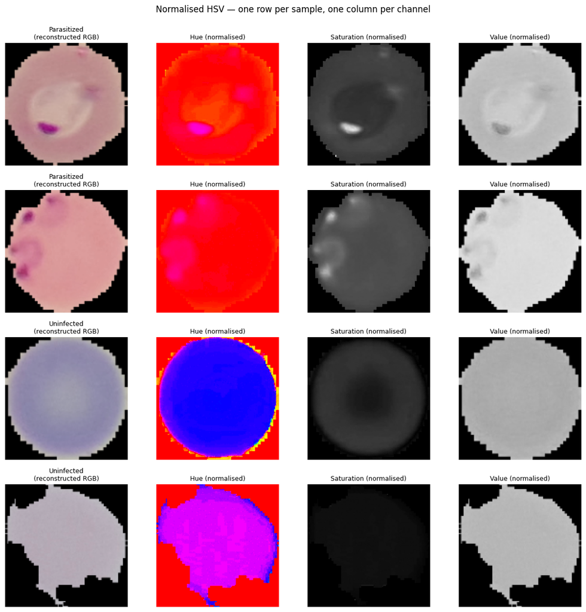

```python
# ── Sanity-check ranges, then plot a small per-channel preview ──────────────

# Confirm every channel really lies in [0, 1] post-normalisation.
for _ch, _name in enumerate(['Hue', 'Saturation', 'Value']):
    _lo, _hi = float(train_hsv_norm[:,:,:,_ch].min()), float(train_hsv_norm[:,:,:,_ch].max())
    say(this=f"`{_name:<10}` train range: `[{_lo:.3f}, {_hi:.3f}]`")

# Pick four reproducible sample indices (the global NumPy seed is fixed earlier).
_n_samples = 4
_idx = np.random.default_rng(SEED).choice(len(train_hsv_norm), _n_samples, replace=False)

# Grid: rows = samples, cols = (composite, H, S, V).
fig, axes = plt.subplots(_n_samples, 4, figsize=(12, 3 * _n_samples))
fig.suptitle('Normalised HSV — one row per sample, one column per channel',
             fontsize=12, y=0.995)

for _row, _i in enumerate(_idx):
    _hsv = train_hsv_norm[_i]                            # (H, W, 3) float32 in [0, 1]
    _label = class_names[int(train_labels[_i])]

    # Reconstruct an RGB preview from the normalised HSV array. We undo the
    # per-channel scaling, cast back to uint8, then convert HSV→RGB so the
    # composite column shows what the model would "see" after de-norm.
    _hsv_uint8 = np.empty_like(_hsv, dtype=np.uint8)
    _hsv_uint8[..., 0] = (_hsv[..., 0] * 179.0).round().astype(np.uint8)
    _hsv_uint8[..., 1] = (_hsv[..., 1] * 255.0).round().astype(np.uint8)
    _hsv_uint8[..., 2] = (_hsv[..., 2] * 255.0).round().astype(np.uint8)
    _rgb_preview = cv2.cvtColor(_hsv_uint8, cv2.COLOR_HSV2RGB)

    axes[_row, 0].imshow(_rgb_preview)
    axes[_row, 0].set_title(f"{_label}\n(reconstructed RGB)", fontsize=9)
    axes[_row, 0].axis('off')

    # Channel-by-channel grayscale heatmaps; vmin/vmax fixed at [0, 1] so the
    # colour scale is comparable across samples.
    for _col, (_ch, _cname, _cmap) in enumerate(
        [(0, 'Hue', 'hsv'), (1, 'Saturation', 'gray'), (2, 'Value', 'gray')], start=1
    ):
        axes[_row, _col].imshow(_hsv[..., _ch], cmap=_cmap, vmin=0.0, vmax=1.0)
        axes[_row, _col].set_title(f"{_cname} (normalised)", fontsize=9)
        axes[_row, _col].axis('off')

plt.tight_layout()
plt.show()
```

## Model Building

*(With the data prepared we now switch focus from "what's in the images" to "what learns from them". The next several cells set up the deep-learning environment — quieting log messages, importing TensorFlow/Keras, detecting available hardware, fixing random seeds, and converting the labels into a form the loss function can consume.)*

### Importing Libraries

```python
# ─── Silence the noisy log messages TensorFlow prints on import ───────────────
# These environment variables have to be set BEFORE TensorFlow is imported in
# the next cell — otherwise TF reads them too late and the chatter still appears.
# None of these flags affect correctness, only how much output you see.

os.environ['TF_CPP_MIN_LOG_LEVEL'] = '2'      # hide INFO + WARNING from C++ logs
os.environ['TF_ENABLE_ONEDNN_OPTS'] = '0'     # skip oneDNN notices
os.environ['TF_METAL_VERBOSE'] = '0'          # silence metal_plugin banner

import absl.logging                            # absl is the Google logging library Keras uses
absl.logging.set_verbosity(absl.logging.ERROR)  # hide Keras/absl INFO
```

```python
# ─── Import the TensorFlow / Keras building blocks used in Part 2 ─────────────
# We import every name we will need across the next ~30 cells in one place so
# the model-construction cells stay short and easy to read.

# TensorFlow — Google's deep-learning framework. `tf` is the standard alias.
import tensorflow as tf
# Keras — TensorFlow's high-level model-building API. Since TF 2.x, Keras ships inside TF.
from tensorflow import keras
# layers  → the building blocks of a model: Conv2D, Dense, Dropout, etc.
# models  → container classes: Sequential (linear stack), Model (functional API)
from tensorflow.keras import layers, models
# Adam — an adaptive optimiser; see the CNN Primer cell for what an optimiser is.
from tensorflow.keras.optimizers import Adam

# to_categorical → one-hot encodes integer labels into probability vectors
from tensorflow.keras.utils import to_categorical
# EarlyStopping → halt training when validation metric stops improving
# ReduceLROnPlateau → shrink the learning rate when progress plateaus
from tensorflow.keras.callbacks import EarlyStopping, ReduceLROnPlateau
# ImageDataGenerator → generates augmented image batches on the fly for Model 3
from tensorflow.keras.preprocessing.image import ImageDataGenerator
# VGG16 → pre-trained ImageNet model for transfer learning (the final model in Part 2)
from tensorflow.keras.applications import VGG16
```

```python
# ─── Sanity-check the TensorFlow and Keras versions ───────────────────────────
# Pinning down the versions in the notebook output makes results reproducible —
# if you re-run this two years from now and accuracy differs, the version table
# tells you whether a TF/Keras upgrade is the likely cause.
say(this=f"""
| Librsry | Version |
|-|-|
| Tensorflow | `{tf.__version__}` |
| Keras      | `{keras.__version__}`
""")
```

| Librsry | Version |
| --- | --- |
| Tensorflow | `2.16.2` |

[output not shown]

### Hardware Detection

Training a CNN involves billions of multiply-add operations per epoch. Running them on a CPU (which processes instructions largely sequentially across a handful of cores) takes tens of minutes per epoch; running them on a GPU (which executes thousands of arithmetic operations in parallel across dedicated matrix-math hardware) takes seconds. Detecting which device is available and pointing TensorFlow at it is therefore the single biggest performance decision of the whole pipeline.

*(Beginner intuition: think of the CPU as one or two senior chefs cooking dishes one at a time, and the GPU as a kitchen of a thousand junior cooks each chopping their own onion. Most CNN operations — convolutions, matrix multiplications — are exactly the kind of "many tiny identical operations" that thousand junior cooks are great at and a senior chef is wasted on.)*

This cell picks the fastest available TensorFlow compute device and seeds TensorFlow's random number generator. Detection happens in **strict priority order** — the first match wins, the rest are not considered:

1. **Apple Silicon GPU** (M1 / M2 / M3 / M4 Mac via the `tensorflow-metal` plugin) — fastest on modern Macs. The M-series chips integrate a GPU with unified memory access to the CPU, eliminating the PCIe data-transfer bottleneck. Apple's Metal API exposes this GPU to TensorFlow through a separately-installed plugin (`pip install tensorflow-metal`). Without the plugin, the Mac falls through to CPU even on capable hardware.
2. **NVIDIA GPU** (CUDA) — the default GPU path in cloud environments. Colab, Kaggle, and most ML workstations come with NVIDIA cards (T4, A100, V100, RTX 40-series, etc.) and TensorFlow talks to them via CUDA. TF memory-growth management (see the code below) is specifically needed here because CUDA's default is to grab all available VRAM eagerly.
3. **CPU fallback** — works everywhere; roughly 10–30× slower than either GPU path for this dataset. A full Part 2 training run (five models) takes ~5 minutes on a T4 GPU vs ~90 minutes on CPU. The notebook will still complete end-to-end on CPU, just slowly.

**How detection works.** TensorFlow's `list_physical_devices('GPU')` returns the same type of PhysicalDevice object regardless of whether the underlying hardware is Apple Silicon or NVIDIA — so the call alone cannot distinguish the two. The workaround is to first probe the operating system and CPU architecture via Python's `platform` module: if `platform.system() == 'Darwin'` (macOS) and `platform.processor() == 'arm'` (ARM architecture, meaning an M-series chip rather than an older Intel Mac), any GPU TensorFlow reports must be the Metal-backed Apple GPU. If the platform check fails but TF still reports a GPU, we're on NVIDIA. If TF reports no GPU, we're on CPU.

**Memory growth — NVIDIA only.** On NVIDIA hardware, TensorFlow by default allocates *all* available GPU memory on first use, even if the model needs a fraction. This breaks multi-tenant environments (Colab free tier, shared lab GPUs, local dev machines running other ML workloads) because it blocks every other process. Calling `tf.config.experimental.set_memory_growth(gpu, True)` before any GPU ops run tells TF to allocate incrementally instead. The Metal backend on Apple Silicon manages memory through the unified CPU/GPU memory pool automatically, so this API is a no-op there — we skip it on Apple Silicon to avoid a benign but noisy warning.

**Random seeding.** Finally, `tf.random.set_seed(SEED)` fixes TensorFlow's internal random number generator. This controls weight initialisation (the starting point of training), dropout masks, and any `shuffle=True` operations in `fit()`. Combined with the NumPy seed we set in Part 1, this gives fully reproducible runs as long as the hardware is consistent. Note: GPU non-determinism from parallel reduction ops can still introduce ±0.1% variation run-to-run even with seeds fixed — eliminable via `TF_DETERMINISTIC_OPS=1` at a modest speed cost.

*(In one sentence: this section makes training fast where possible, makes runs reproducible where possible, and silently degrades to whatever your hardware actually supports.)*

PyTorch's equivalent setup is deferred to Part 3 where it is first used — it has its own device-detection API and its own seed call.

*(Lazy setup: we only configure a framework when we actually need it. Loading PyTorch here would just add memory pressure for nothing.)*

```python
# ─── Detect the fastest available TensorFlow device and configure it ─────────
# Goal of this cell:
#   1. Decide whether we have an Apple-Silicon GPU, an NVIDIA GPU, or only a CPU.
#   2. On NVIDIA, switch on incremental memory allocation (so we don't grab all VRAM).
#   3. Fix TensorFlow's RNG seed for reproducibility.
# All output is summarised in the markdown table at the bottom of the cell.

# platform  →  already imported in Environment Detection cell

# ── Probe the platform for Apple Silicon first ───────────────────────────────
# On macOS 11+ with an M-series chip AND the `tensorflow-metal` plugin installed,
# TensorFlow exposes the GPU via Apple's Metal API. The device still shows up
# in list_physical_devices('GPU'), so to distinguish Apple Silicon from NVIDIA
# we probe the OS and CPU architecture directly.
is_apple_silicon = (
    platform.system() == 'Darwin'          # Running on macOS
    and platform.processor() == 'arm'      # ARM-based CPU (not x86 Intel Mac)
)

# ── Ask TensorFlow what GPUs it can see ─────────────────────────────────────
# Returns a list of PhysicalDevice objects — one per visible GPU.
# Empty list means CPU only.
tf_gpus = tf.config.list_physical_devices('GPU')

# ── Resolve to one of three device categories, in priority order ────────────
# Priority is intentional: Apple-Silicon Metal is preferred on M-series Macs,
# NVIDIA CUDA is the cloud default, CPU is the universal fallback.
if tf_gpus and is_apple_silicon:
    tf_device  = 'Apple Silicon GPU (Metal)'
    tf_details = f"{len(tf_gpus)}× Metal device, {platform.machine()}"
elif tf_gpus:
    tf_device  = 'NVIDIA GPU (CUDA)'
    tf_details = tf_gpus[0].name
else:
    tf_device  = 'CPU'
    tf_details = f"{platform.processor() or 'unknown CPU'}"

# ── Memory growth — NVIDIA only ─────────────────────────────────────────────
# By default TF grabs ALL available GPU memory at startup, even if the model
# needs only a fraction. On shared environments (Colab free tier, lab servers)
# this blocks other programs. `set_memory_growth(True)` tells TF to allocate
# incrementally as needed. Must be called BEFORE any GPU ops run.
#
# Apple's Metal backend does NOT support the memory_growth API — it manages
# memory unified with the CPU automatically. Calling set_memory_growth on a
# Metal device raises a warning, so we skip it for Apple Silicon.
if tf_gpus and not is_apple_silicon:
    for gpu in tf_gpus:                    # support multi-GPU rigs too
        try:
            tf.config.experimental.set_memory_growth(gpu, True)
        except RuntimeError:
            # If TF has already initialised the GPU, this call raises. Swallow
            # it quietly — the first run still gets memory growth; subsequent
            # cell re-runs just skip the flag change.
            pass

# Seed TensorFlow's RNG (separate from NumPy's). This controls weight
# initialisation and any randomness inside TF ops.
tf.random.set_seed(SEED)

# Print the resolved configuration as a small Markdown table for the run log.
say(this=f"""
**TensorFlow hardware configuration:**

| Framework | Device | Details |
|-----------|--------|---------|
| TensorFlow / Keras | `{tf_device}` | `{tf_details}` |

**TensorFlow random seed fixed at `{SEED}` ✅**
""")
```

**TensorFlow hardware configuration:**

| Framework | Device | Details |
| --- | --- | --- |
| TensorFlow / Keras | `Apple Silicon GPU (Metal)` | `1× Metal device, arm64` |

**TensorFlow random seed fixed at `42` ✅**

### ❓ Key Questions — Model Building

> **Q: Are results reproducible across runs? Without fixed random seeds, reported accuracies can vary by 1–2% between identical runs, making model comparisons unreliable.** Recommended solution: Set seeds for Python, NumPy, and TensorFlow at the top of the model building section, before any model is constructed or data is shuffled. GPU non-determinism is harder to eliminate but can be reduced by setting `TF_DETERMINISTIC_OPS`.

> *(Why three seeds, not one? Each library has its **own** random number generator. Python's `random.seed` controls vanilla `random.choice`, NumPy's `np.random.seed` controls NumPy operations, TensorFlow's `tf.random.set_seed` controls TF ops. Seeding only one of them leaves the others free to produce different sequences each run.)*

```python
# ─── Fix the RNG seed across every random library we use ─────────────────────
# We do this BEFORE any model is built or any data is shuffled, so that:
#   • Weight initialisation gives the same starting point each run.
#   • Dropout masks repeat the same pattern.
#   • Any np.random.permutation we run picks the same indices.
# Without these calls, two identical runs could differ by ±1–2% in accuracy.

# random, os  →  already imported in earlier cells
SEED = 42                                  # 42 is convention; any int works
random.seed(SEED)                          # vanilla Python random
np.random.seed(SEED)                       # NumPy RNG (used by sklearn, pandas, etc.)
tf.random.set_seed(SEED)                   # TensorFlow ops + Keras layer init
os.environ['TF_DETERMINISTIC_OPS'] = '1'   # forces deterministic GPU kernels (slower, but reproducible)

say(this=f"**Random seeds fixed at `{SEED}` for Python, NumPy, and TensorFlow ✅**")
```

**Random seeds fixed at `42` for Python, NumPy, and TensorFlow ✅**

### One-Hot Encoding the Labels

Our labels are currently stored as integers: `0` for Parasitized, `1` for Uninfected. But our Keras model's output layer will be `Dense(2, activation='softmax')` — a fully-connected layer with 2 neurons (one per class) followed by the **softmax** activation function, which converts the neurons' raw scores into a probability distribution (non-negative values that sum to 1), e.g. `[0.97, 0.03]` meaning "97% confident it's Parasitized, 3% confident it's Uninfected". To compute loss, the model's output must be compared against a target in the **same shape and space** as the output. That's what one-hot encoding does: it converts each integer label into a probability vector that's 100% concentrated on the correct class.

*(Beginner intuition: imagine asking the model "which of these two boxes is the cat in?" The model points at one box with some confidence, e.g. "70% box A, 30% box B". To grade the answer we need to know the truth in the same form — "100% box A, 0% box B" — so we can compare the two distributions. One-hot encoding is just writing the truth in that probabilistic form.)*

| Original label | One-hot vector | Meaning |
| --- | --- | --- |
| `0` | `[1, 0]` | 100% probability this is Parasitized |
| `1` | `[0, 1]` | 100% probability this is Uninfected |

**Why it's needed here.** The loss function for this model is `categorical_crossentropy`, which computes the "distance" between the predicted probability distribution and the target distribution. It requires both to be vectors of the same shape — a raw integer `0` won't work; `[1, 0]` will.

*(Quick definitions:* *- **Categorical cross-entropy** = a number measuring how surprised the model would be if the truth were revealed. Predicting `[0.99, 0.01]` when the truth is `[1, 0]` gives a tiny loss; predicting `[0.01, 0.99]` when the truth is `[1, 0]` gives a huge loss.* *- **Why categorical and not binary?** Even though we have only 2 classes, we use a 2-neuron softmax + categorical_crossentropy because it generalises trivially to 3, 4, … classes. The mathematically equivalent alternative — 1-neuron sigmoid + binary_crossentropy — only works for exactly 2 classes and forces a slightly different output shape, so we pick the more flexible setup.)*

**When one-hot encoding is appropriate generally:**

- ✅ **Labels for softmax-output networks with `categorical_crossentropy`** — exactly this project's case.
- ✅ **Nominal categorical features** passed into a neural network input layer — e.g. a "staining brand" feature with no natural ordering. Encoding as integers would falsely suggest an ordering.
- ❌ **Not needed with `sparse_categorical_crossentropy`** (Keras) or `nn.CrossEntropyLoss` (PyTorch) — these loss functions accept integer labels directly and apply the one-hot transformation internally. This is why Part 3's PyTorch implementation stores labels as `torch.long` integers, not one-hot vectors, and it is exactly equivalent.
- ❌ **Not appropriate for ordinal features** with a meaningful ordering (low/medium/high, 1–5 star ratings). Ordinal encoding preserves the ordering; one-hot destroys it.
- ❌ **Not appropriate for very high-cardinality features** (thousands of categories). Use learned embeddings instead, which produce a dense 16–256-dimensional vector per category rather than a sparse vector as wide as the vocabulary.
- ❌ **Not typically used with tree-based models** (Random Forest, XGBoost). They handle categorical variables natively and one-hot often fragments their split decisions.

In this project, one-hot encoding is applied exactly once — here, to the labels fed to every Keras model in Part 2. The PyTorch models in Part 3 skip it (they use integer labels with `nn.CrossEntropyLoss`), and the Part 5 Keras models also skip the explicit call because `flow_from_directory(..., class_mode='categorical')` does it internally inside the generator. All three approaches produce identical training behaviour.

*(Take-away: one-hot is a **labelling convention**, not a different algorithm. As long as the loss function and the label format agree with each other, the maths underneath is the same.)*

```python
# ─── One-hot encode the labels and (critically) shuffle the training arrays ──
# Two jobs in one cell:
#   1. Convert integer labels (0, 1) into 2-element probability vectors so they
#      match the model's softmax output and can be compared with categorical
#      cross-entropy.
#   2. Shuffle the train arrays in a deterministic, reproducible way so that the
#      validation_split=0.1 used downstream takes a balanced 50/50 slice.

# Two classes — the CNNs will have `Dense(2, activation='softmax')` at the top,
# producing a 2-element probability vector that sums to 1.
num_classes = 2

# to_categorical converts integer labels into one-hot vectors.
#   train_labels.shape before: (24958,)       — 1D array of ints
#   train_labels_ohe.shape after: (24958, 2)  — 2D array of [p0, p1] pairs
# This shape must match the model's output for categorical_crossentropy loss to work.
train_labels_ohe = to_categorical(train_labels, num_classes)
test_labels_ohe  = to_categorical(test_labels,  num_classes)

# ── Shuffle the training arrays in place ────────────────────────────────────
# load_images() appends Parasitized images first, then Uninfected, so both
# train_images_norm and train_labels_ohe are sorted by class. Keras's
# validation_split=0.1 takes the **tail** of the array before shuffling, so
# every downstream .fit(..., validation_split=0.1) would otherwise put 100%
# Uninfected in validation — which causes both Base Model and Model 1 to
# collapse to a single-class prediction.
#
# One deterministic shuffle here fixes all downstream .fit() calls at once.
# np.random.RandomState(42) is used so the permutation is reproducible AND
# independent from the global NumPy RNG seeded earlier.
_shuffle_perm = np.random.RandomState(42).permutation(len(train_images_norm))
train_images_norm = train_images_norm[_shuffle_perm]   # reorder pixels
train_labels_ohe  = train_labels_ohe[_shuffle_perm]    # reorder one-hot labels in lockstep
train_labels      = train_labels[_shuffle_perm]   # keep integer labels aligned too

# Sanity check: the tail 10% should now be roughly 50/50.
# If the shuffle worked, the slice Keras will use as validation should contain
# both classes in roughly equal proportion, NOT 100% of one class.
_tail = train_labels[int(len(train_labels) * 0.9) :]
say(this=f"""
**Validation-slice class balance after shuffle** (last 10% — what `validation_split=0.1` will use):

| Class | Count | Percent |
|-------|-------|---------|
| Parasitized | `{int((_tail == 0).sum())}` | `{(_tail == 0).mean() * 100:.1f}%` |
| Uninfected  | `{int((_tail == 1).sum())}` | `{(_tail == 1).mean() * 100:.1f}%` |

Both should be close to 50% — if they are, the downstream `validation_split` calls will produce a meaningful
`val_accuracy`/`val_loss`.
""")

# Side-by-side comparison so the reader can see the shape change.
say(this=f"""
**One-hot encoding complete:**

| Split | Shape before OHE | Before — Dimensions | Shape after OHE | After — Dimensions |
|-------|------------------|---------------------|-----------------|--------------------|
| Train | `{train_labels.shape}` | N (samples) = `{train_labels.shape[0]}` | `{train_labels_ohe.shape}` | N (samples) = `{train_labels_ohe.shape[0]}`, K (classes) = `{train_labels_ohe.shape[1]}` |
| Test  | `{test_labels.shape}`  | N (samples) = `{test_labels.shape[0]}`  | `{test_labels_ohe.shape}`  | N (samples) = `{test_labels_ohe.shape[0]}`,  K (classes) = `{test_labels_ohe.shape[1]}`  |

Example: label `0` → `[1, 0]` (Parasitized), label `1` → `[0, 1]` (Uninfected)
""")
```

**Validation-slice class balance after shuffle** (last 10% — what `validation_split=0.1` will use):

| Class | Count | Percent |
| --- | --- | --- |
| Parasitized | `1248` | `50.0%` |
| Uninfected | `1248` | `50.0%` |

Both should be close to 50% — if they are, the downstream `validation_split` calls will produce a meaningful `val_accuracy`/`val_loss`.

**One-hot encoding complete:**

| Split | Shape before OHE | Before — Dimensions | Shape after OHE | After — Dimensions |
| --- | --- | --- | --- | --- |
| Train | `(24958,)` | N (samples) = `24958` | `(24958, 2)` | N (samples) = `24958`, K (classes) = `2` |
| Test | `(2600,)` | N (samples) = `2600` | `(2600, 2)` | N (samples) = `2600`, K (classes) = `2` |

Example: label `0` → `[1, 0]` (Parasitized), label `1` → `[0, 1]` (Uninfected)

# Part 2 — TensorFlow / Keras at `IMG_SIZE` Resolution

This part trains **five architectures** at `IMG_SIZE × IMG_SIZE` (computed dynamically in Part 1 — 128 px for this dataset) using TensorFlow/Keras. Transfer learning is limited to VGG16 in this part. More advanced pre-trained models (EfficientNetB0, EfficientNetB3, ResNet50V2, MobileNetV3Large) with two-phase fine-tuning are covered in Part 5.

*(Reminder: **Transfer learning** = take a network that someone else trained on a giant dataset (ImageNet — 1.2 million natural photos) and reuse it as a feature extractor for our own much smaller dataset. The big network already knows how to detect edges, textures and parts; we only need to teach a small classification head on top.)*

> **Why VGG16 only here?** VGG16 establishes the transfer-learning baseline at the dynamic IMG_SIZE. More advanced pre-trained architectures (EfficientNetB0, EfficientNetB3, ResNet50V2, MobileNetV3Large) with two-phase fine-tuning are introduced in Part 5.

## CNN Primer — Vocabulary Used Throughout This Part

Every model in Part 2 is a **convolutional neural network (CNN)** — a specific kind of neural network designed for grid-structured data like images. Before the architecture diagrams and code start using specific layer names, here is what each building block does:

*(One-paragraph overview if you have never seen a CNN. The first layers of a CNN look at small image patches and learn simple patterns — edges, colours, textures. The next layers combine those simple patterns into more complex ones — corners, blobs, ring-like shapes. The last layers combine those into full concepts — "this region looks like a parasite ring". A final classification layer maps that high-level evidence to a probability for each class.)*

[output not shown]

*(Mental model. The primer table above is a glossary you can refer back to whenever you meet a new layer. You don't need to memorise it — most people learn these terms simply by seeing them used in context, which is exactly what the next five models do.)*

The five models below build on each other in a deliberate staircase — each adds one new technique so its effect can be measured in isolation:

1. **Base Model** — minimal 2-block CNN, baseline for comparison
2. **Model 1 (Deeper)** — same idea with more Conv layers and a wider Dense head
3. **Model 2 (BN + LeakyReLU)** — adds BatchNormalization and LeakyReLU for training stability
4. **Model 3 (Augmented)** — same architecture as Model 2 + data augmentation during training
5. **VGG16 Transfer** — frozen ImageNet backbone with our custom classification head